# Day 4: Rmarkdown, RStudio Git, RMD, and Advanced Data Manipulation 1

Amanda Sahar d’Urso (materials from: R.P. Morel

2020-09-03

## Session Outline

- Pull request (theory and practice) by the Wonderful Ali
- Open exercise file, save with name in submissions folder
- RMD and Intro to data manipulation
- Git commit, push, pull **in R studio**
- Pull request your submission to MSiA by the Wonderful Ali

# Reporting analysis with Rmarkdown and GitHub

## Rmarkdown & GitHub

- Rmarkdown creates dynamic reports in HTML, PDF, and Word
- Combine text (using the markdown language) and R code
- Rmarkdown runs R code, compiles, and produces a report in chosen format
- This presentation was created using Rmarkdown!

## Exercises in R

1. Open the `day4_Rmd-datamanip1_exercises.Rmd`
2. Save as: `Day4Exercise_LastnameFirstname.Rmd` within the `submissions` folder
3. Read in the gapminder data set
4. As you answer questions, be sure to annotate your work with as much detail as possible!
5. At the end of the day, we’ll push it over to MSiA

# RMD

## RMD Codes

- The white spaces in RMD look similar to the script, however the white spaces will not run code; they are used to write out sentences like analyses, document headings, etc…
- To work with code, you must initiate a chunk via ```{r} and end it with ```

## Useful specifications, example

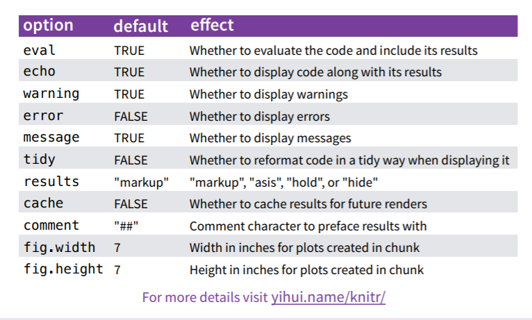

[Useful Cheat Sheet](https://rstudio.com/wp-content/uploads/2015/02/rmarkdown-cheatsheet.pdf)

## Knitting

As you work through your file, you can knit it to different formats in order to see what it looks like. Ultimately you can share the output as a document or memo.

- knit to pdf requires Latex
- knit options are specified manually when pressing the arrow next to knit

[figure not shown]

# Advanced data manipulation, part 1: reshaping and merging

## A new dataset

California energy data

- file names: `ca_energy_generation.csv` and `ca_energy_imports.csv`
- Read these two files into your working environment
  - They are in the “data” folder

## Reading in the data

```r
library(tidyverse)
generation <- read_csv("../data/ca_energy_generation.csv")
imports <- read_csv("../data/ca_energy_imports.csv")
```

## Tidy data: What the heck is the `tidyverse`?

- “System of packages for data manipulation, exploration, and visualization that share a common design philosophy” - Rickert
- Mainly developed by Hadley Wickham
- These packages work together using consistent language structures—once you learn it, these packages will feel as one

## Tidy data: Tidyverse packages

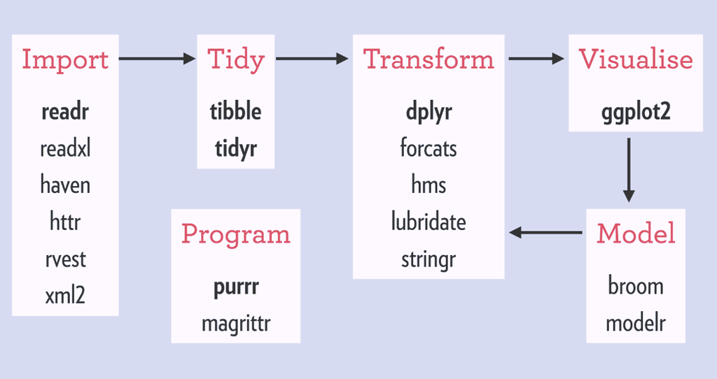

## What is Tidy Data?

- “Happy families are all alike; every unhappy family is unhappy in its own way” - Leo Tolstoy
- “Tidy datasets are all alike, but every messy dataset is messy in its own way” - Hadley Wickham
- Basically, tidy data are the way your data should be organized

## Three rules for tidy data:

1. Each variable must have its own column.
2. Each observation must have its own row.
3. Each value must have its own cell.

## 1. Each variable must have its own column

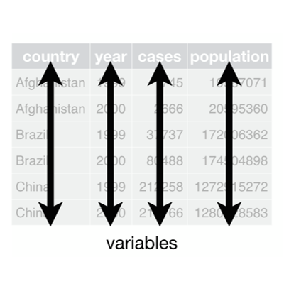

## 2. Each observation must have its own row

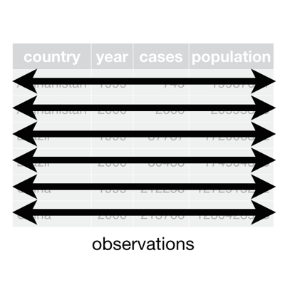

## 3. Each value must have its own cell.

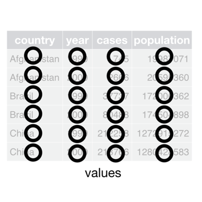

## Long to wide

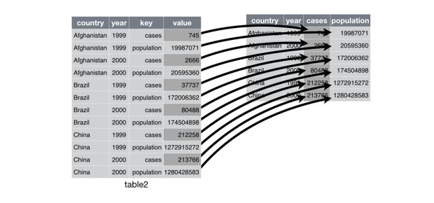

## Wide versus long data

- Often, we want to make wide data long (or tidy) for analysis

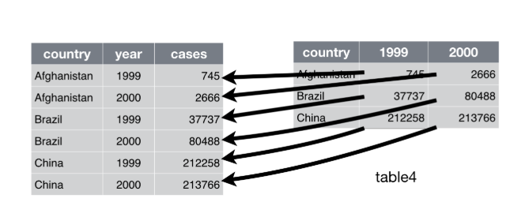

## Wide versus long data

```r
head(generation)
```

```
## # A tibble: 6 x 12
##   datetime            biogas biomass  coal geothermal large_hydro
##   <dttm>               <dbl>   <dbl> <dbl>      <dbl>       <dbl>
## 1 2019-09-03 00:00:00   239.    407.  9          967.       3152.
## 2 2019-09-03 01:00:00   239     406.  9          970.       2724.
## 3 2019-09-03 02:00:00   239     407.  9          973.       2630
## 4 2019-09-03 03:00:00   239.    407.  9.83       974.       2611.
## 5 2019-09-03 04:00:00   238.    406.  9.42       975.       2651.
## 6 2019-09-03 05:00:00   237.    409. 10          973.       2966.
## # ... with 6 more variables: natural_gas <dbl>, nuclear <dbl>,
## #   other <dbl>, small_hydro <dbl>, solar <dbl>, wind <dbl>
```

- `gather` –> make data long
- `spread` –> make data wide

## Reshaping CA energy data

- Right now, the `generation` dataframe has several observations per row

```r
head(generation)
```

```
## # A tibble: 6 x 12
##   datetime            biogas biomass  coal geothermal large_hydro
##   <dttm>               <dbl>   <dbl> <dbl>      <dbl>       <dbl>
## 1 2019-09-03 00:00:00   239.    407.  9          967.       3152.
## 2 2019-09-03 01:00:00   239     406.  9          970.       2724.
## 3 2019-09-03 02:00:00   239     407.  9          973.       2630
## 4 2019-09-03 03:00:00   239.    407.  9.83       974.       2611.
## 5 2019-09-03 04:00:00   238.    406.  9.42       975.       2651.
## 6 2019-09-03 05:00:00   237.    409. 10          973.       2966.
## # ... with 6 more variables: natural_gas <dbl>, nuclear <dbl>,
## #   other <dbl>, small_hydro <dbl>, solar <dbl>, wind <dbl>
```

## `gather` the generation data

`gather(df, key = new column name for key variable, value = new column name for data)`

- Specify the variable that *doesn’t* gather through `-variable` (or specify the ones you want to gather)

```r
long_gen <- gather(generation, key = source, value = usage, -datetime)
head(long_gen)
```

```
## # A tibble: 6 x 3
##   datetime            source usage
##   <dttm>              <chr>  <dbl>
## 1 2019-09-03 00:00:00 biogas  239.
## 2 2019-09-03 01:00:00 biogas  239
## 3 2019-09-03 02:00:00 biogas  239
## 4 2019-09-03 03:00:00 biogas  239.
## 5 2019-09-03 04:00:00 biogas  238.
## 6 2019-09-03 05:00:00 biogas  237.
```

## reordering the `gather` the generation data by time

```r
head(long_gen[order(long_gen$datetime), ])
```

```
## # A tibble: 6 x 3
##   datetime            source      usage
##   <dttm>              <chr>       <dbl>
## 1 2019-09-03 00:00:00 biogas       239.
## 2 2019-09-03 00:00:00 biomass      407.
## 3 2019-09-03 00:00:00 coal           9
## 4 2019-09-03 00:00:00 geothermal   967.
## 5 2019-09-03 00:00:00 large_hydro 3152.
## 6 2019-09-03 00:00:00 natural_gas 9711.
```

```r
spread(long_gen, key = source, value = usage) %>% slice(1:5)
```

```
## # A tibble: 5 x 12
##   datetime            biogas biomass  coal geothermal large_hydro
##   <dttm>               <dbl>   <dbl> <dbl>      <dbl>       <dbl>
## 1 2019-09-03 00:00:00   239.    407.  9          967.       3152.
## 2 2019-09-03 01:00:00   239     406.  9          970.       2724.
## 3 2019-09-03 02:00:00   239     407.  9          973.       2630
## 4 2019-09-03 03:00:00   239.    407.  9.83       974.       2611.
## 5 2019-09-03 04:00:00   238.    406.  9.42       975.       2651.
## # ... with 6 more variables: natural_gas <dbl>, nuclear <dbl>,
## #   other <dbl>, small_hydro <dbl>, solar <dbl>, wind <dbl>
```

# Dealing with dates/time

## Dealing with dates and times

- Notice that the first variable in both dataset is the called “datetime”
- What class are these variables?

```r
class(generation$datetime)
```

```
## [1] "POSIXct" "POSIXt"
```

```r
class(imports$datetime)
```

```
## [1] "POSIXct" "POSIXt"
```

## Dealing with dates/times: `lubridate`

- The best way to deal with date-time data is to use the `lubridate` package
- You can convert character variables into datetime format using the `as_datetime` function
  - One advantage of `readr::read_csv` is that it will often detect and convert datetime variables when importing

```r
library(lubridate)
```

## Dealing with dates/times with `lubridate`

```r
generation$datetime <- as_datetime(generation$datetime)
head(generation$datetime)
```

```
## [1] "2019-09-03 00:00:00 UTC" "2019-09-03 01:00:00 UTC"
## [3] "2019-09-03 02:00:00 UTC" "2019-09-03 03:00:00 UTC"
## [5] "2019-09-03 04:00:00 UTC" "2019-09-03 05:00:00 UTC"
```

```r
imports$datetime <- as_datetime(imports$datetime)
head(imports$datetime)
```

```
## [1] "2019-09-03 00:00:00 UTC" "2019-09-03 01:00:00 UTC"
## [3] "2019-09-03 02:00:00 UTC" "2019-09-03 03:00:00 UTC"
## [5] "2019-09-03 04:00:00 UTC" "2019-09-03 05:00:00 UTC"
```

# Merging data

## Merging CA energy data

- Sometimes you have data from two (or more) sources that you want to analyze
- Need to merge these dataframes together
- To merge, need to chose the columns that have common values between the dataframes
- Usually a variable with ids or years, or both

## Merging the `merge`

`merge(x, y, by = c("id", "year"))`

- Key arguments:
- `x`: first dataframe
- `y`: second dataframe
- `by`: variables to match (must have common name)

## More `merge` arguments

```r
merge(x, y, by.x = "id", by.y = "cd", all.x = T, all.y = T)
```

- Advanced arguments:
- Use `by.x` and `by.y` if the dataframes have different variable names
- Use `all.x = T` if you want to keep all the observation in the first dataframe (unmatched observations in `y` are dropped!)
- Use `all.y = T` if you want to keep all observations in the second dataframe (umatched observations in `x` are dropped!)
- Use both (or, simply `all = T`) to keep all observations!
- By **default** R will drop unmatched observations from **both** dataframes!

## Merge by `datetime`

- Use `merge` to join the `generation` and `imports` dataframes, using the `datetime` variable to match

## Merge by `datetime`

- Always check your merge!

```r
merged_energy <- merge(generation, imports, by = "datetime")
dim(merged_energy)
```

```
## [1] 168  13
```

```r
head(merged_energy)
```

```
##              datetime   biogas  biomass      coal geothermal large_hydro
## 1 2019-09-03 00:00:00 238.9167 407.0833  9.000000   967.2500    3152.500
## 2 2019-09-03 01:00:00 239.0000 406.5000  9.000000   970.3333    2724.333
## 3 2019-09-03 02:00:00 239.0000 406.8333  9.000000   973.1667    2630.000
## 4 2019-09-03 03:00:00 238.9167 407.1667  9.833333   973.8333    2611.250
## 5 2019-09-03 04:00:00 237.9167 406.0833  9.416667   974.6667    2651.333
## 6 2019-09-03 05:00:00 237.1667 408.9167 10.000000   973.3333    2965.500
##   natural_gas  nuclear other small_hydro solar     wind  imports
## 1    9710.833 2248.750     0    401.6667     0 2670.167 7527.333
## 2    9155.000 2250.583     0    400.9167     0 2778.833 6930.333
## 3    8078.333 2250.833     0    413.5833     0 2795.250 7005.833
## 4    7801.250 2245.000     0    359.9167     0 2582.583 7080.583
## 5    7744.333 2242.833     0    382.0833     0 2397.417 7421.667
## 6    8624.583 2242.833     0    395.9167     0 2327.000 7511.667
```

## Try reshaping the merged data!

- Our merged dataframe is still wide and untidy
- Create a long version called `long_merged_energy`
- Take a peek to make sure the long version looks correct

## Try reshaping the merged data!

```r
long_merged_energy <- gather(merged_energy, key = source, value = usage, -datetime)
head(long_merged_energy)
```

```
##              datetime source    usage
## 1 2019-09-03 00:00:00 biogas 238.9167
## 2 2019-09-03 01:00:00 biogas 239.0000
## 3 2019-09-03 02:00:00 biogas 239.0000
## 4 2019-09-03 03:00:00 biogas 238.9167
## 5 2019-09-03 04:00:00 biogas 237.9167
## 6 2019-09-03 05:00:00 biogas 237.1667
```